# Phylogenetic Inference of Formosan Languages

SK

11/15/2021

# Introduction

- The linguistic phylogeny of Austronesian languages is still under-studied.
- computational methods for inferring linguistic phylogenies (**phylogenetic inference**)
  - maximum parsimony;
  - distance-based methods (UPGMA and neighbor joining); and
  - maximum likelihood estimation.

- the results are interesting but still controversial/intractable.
- DNNs are not in and of themselves “superior” to traditional methods.

## terms

- An **unrooted tree** is a phylogenetic tree without a defined root. Unrooted trees provide no information about the temporal sequence of lineage-splitting events. See further Baum & Smith (2013: 61–64).

```r
library(ape)
#library(phangorn)
library(ggplot2)
```

# Dataset

Following Dunn et al(2005) on the phylogenetic classification of Papuan and Oceanic languages using grammatical features.

```r
require(languageR)
require(tidyverse)
#austroTW <- read.table("austroTW", header=T)
#austroTW <- read_csv("formosan_lgs.csv")
# extended version from Willy,csv transposed
austroTW <- read_csv("formosan_dummies.csv") %>% rename(Language=Feature)
head(austroTW, 10)
```

```
## # A tibble: 10 × 62
##    Language  voicedbilabialn… voicelessbilabi… voicedbilabialp… voicedbilabiali…
##    <chr>                <dbl>            <dbl>            <dbl>            <dbl>
##  1 Central …                1                1                1                0
##  2 Squliq A…                1                1                0                0
##  3 Northern…                1                1                1                0
##  4 Isbukun …                1                1                0                1
##  5 Puyuma                   1                1                1                0
##  6 Budai Ru…                1                1                1                0
##  7 Tsou                     1                1                0                1
##  8 Saisiyat                 1                1                0                0
##  9 Yami                     1                1                1                0
## 10 Thao                     1                1                1                0
## # … with 57 more variables: voicelessbilabialnonsibilantfricative <dbl>,
## #   voicedbilabialnonsibilantfricative <dbl>,
## #   voicelesslabiodentalnonsibilantfricative <dbl>,
## #   voicedlabiodentalnonsibilantfricative <dbl>,
## #   voicelessdentalnonsibilantfricative <dbl>,
## #   voiceddentalnonsibilantfricative <dbl>, voicedalveolarnasal <dbl>,
## #   voicelessalveolarplosive <dbl>, voicedalveolarplosive <dbl>, …
```

```r
colnames(austroTW)
```

```
##  [1] "Language"
##  [2] "voicedbilabialnasal"
##  [3] "voicelessbilabialplosive"
##  [4] "voicedbilabialplosive"
##  [5] "voicedbilabialimplosive"
##  [6] "voicelessbilabialnonsibilantfricative"
##  [7] "voicedbilabialnonsibilantfricative"
##  [8] "voicelesslabiodentalnonsibilantfricative"
##  [9] "voicedlabiodentalnonsibilantfricative"
## [10] "voicelessdentalnonsibilantfricative"
## [11] "voiceddentalnonsibilantfricative"
## [12] "voicedalveolarnasal"
## [13] "voicelessalveolarplosive"
## [14] "voicedalveolarplosive"
## [15] "voicedalveolarimplosive"
```

[output cut: 47 more lines]

```r
#austroTW[1:5,1:5]
```

> 是否加入區域訊息探索？ 只加入語音訊息結果如何？

```r
region = c("Eastern", "Northern", "Southern", "Southern", "Southern", "Southern", "Tsouic", "Northern", "Other", "Northern", "Eastern", "Northern", "Eastern", "Northern", "Tsouic", "Tsouic")
names(region) = austroTW$Language
austroTW$Geo = region

austroTW <- austroTW %>%
  select(Language, Geo, everything())

austroTW$Geo <- factor(austroTW$Geo, levels=names(sort(-table(region))))
```

[output not shown]

# Methods

## Dendrogram obtained by applying **divisive clustering** and visualization

```r
library(cluster)

pdf("diana.pdf", width=7, height=4.5)
# austroTW.dist <- dist(austroTW[ ,2:ncol(austroTW)], method="binary")
# get vector of names
plotnames = as.character(austroTW$Language)

plot(diana(dist(austroTW[,3:ncol(austroTW)],
                method="binary")),
     labels = plotnames, cex = 0.8,
     main= " ", xlab= " ", col=c("black","white"), which.plot = 2)

dev.off()
```

## Phylogeny estimation

- Using **neighbor-joining algorithm** to obtain an unrooted phylogenetic tree.
- (options):
  - use different fonts to highlight subsets of observations;
  - get the names of the languages into the plot.
  - `type=u` requests an unrooted tree.

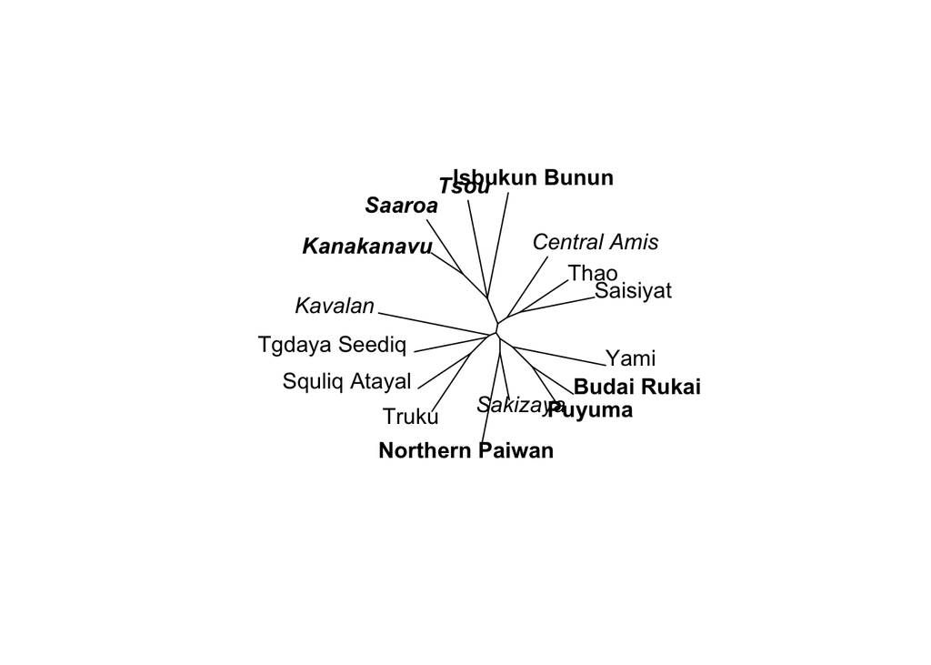

```r
library(ape)
austroTW.dist <- dist(austroTW[ ,3:ncol(austroTW)], method="binary")
austroTW.dist.tr <- nj(austroTW.dist)

Geo <- as.character(austroTW$Geo[as.numeric(austroTW.dist.tr$tip.label)])

languages <- as.character(austroTW$Language[as.numeric(austroTW.dist.tr$tip.label)])
#substitute the language names for the row names in the tree object
#languages[languages=="Yami"] = "(Yami)"
austroTW.dist.tr$tip.label = languages

geo_label <- as.numeric(austroTW$Geo)
geo_label[geo_label==5] <- 6
plot(austroTW.dist.tr, type="u", font = geo_label)
```

- 可以加入 geographical areas (Li) 產生 unrooted phylogenetic trees

## Validation

- using `BOOTSTRAP` to validate a cluster.

```r
# define the num. of bootstrap runs, prepare a list which we save the bootstrap trees
B = 200
btr = list()
length(btr) = B
```

- create 200 bootstrap trees, sampling with replacement from the columns of our data matrix

```r
formosan.mat = austroTW[, 2:ncol(austroTW)]
formosan.meta = austroTW[ ,1]
for(i in 1:B) {
  trB = nj(dist(formosan.mat[ ,sample(ncol(formosan.mat), replace = TRUE)],
                method = "binary"))
  trB$tip.label = as.character(formosan.meta$Language[as.numeric(trB$tip.label)])
  btr[[i]] = trB
}
```

[output not shown]

[output cut: 340 more lines]

[output not shown]

- The proportions of bootstrap trees that support the subtrees of our original tree are obtained with the help of `prop.clades()`

```r
props = prop.clades(austroTW.dist.tr, btr)/B
props
```

```
##  [1] 1.000 0.255 0.115 0.155 0.105 0.195 0.450 0.490 0.505 0.325 0.465 0.655
## [13] 0.805 0.780
```

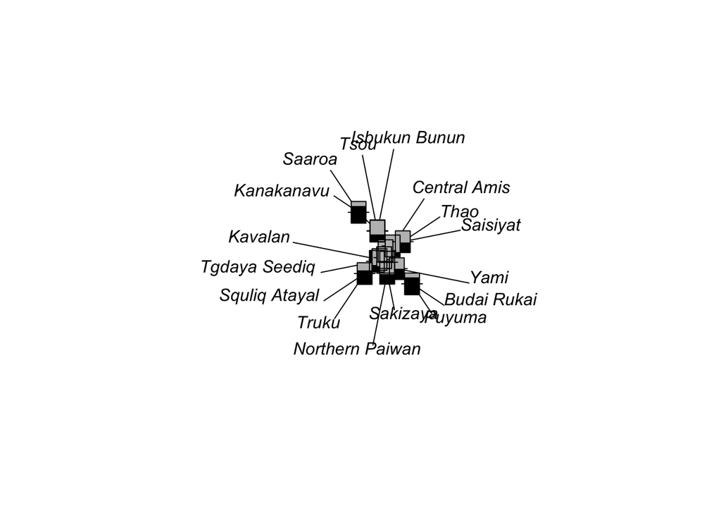

```r
plot(austroTW.dist.tr, type = "u")
# add the thermometers
nodelabels(thermo = props, piecol = c("black", "grey"))
```

## Consensus tree

```r
btr.consensus = consensus(btr, p = 0.5)
```

```r
x = btr.consensus$tip.label; x
```

```
##  [1] "Central Amis"    "Squliq Atayal"   "Northern Paiwan" "Isbukun Bunun"
##  [5] "Puyuma"          "Budai Rukai"     "Tsou"            "Saisiyat"
##  [9] "Yami"            "Thao"            "Kavalan"         "Truku"
## [13] "Sakizaya"        "Tgdaya Seediq"   "Saaroa"          "Kanakanavu"
```

```r
x = data.frame(Language = x, Node = 1:length(x))
x = merge(x, formosan.meta, by.x = "Language", by.y = "Language")
head(x)
```

```
##          Language Node
## 1     Budai Rukai    6
## 2    Central Amis    1
## 3   Isbukun Bunun    4
## 4      Kanakanavu   16
## 5         Kavalan   11
## 6 Northern Paiwan    3
```

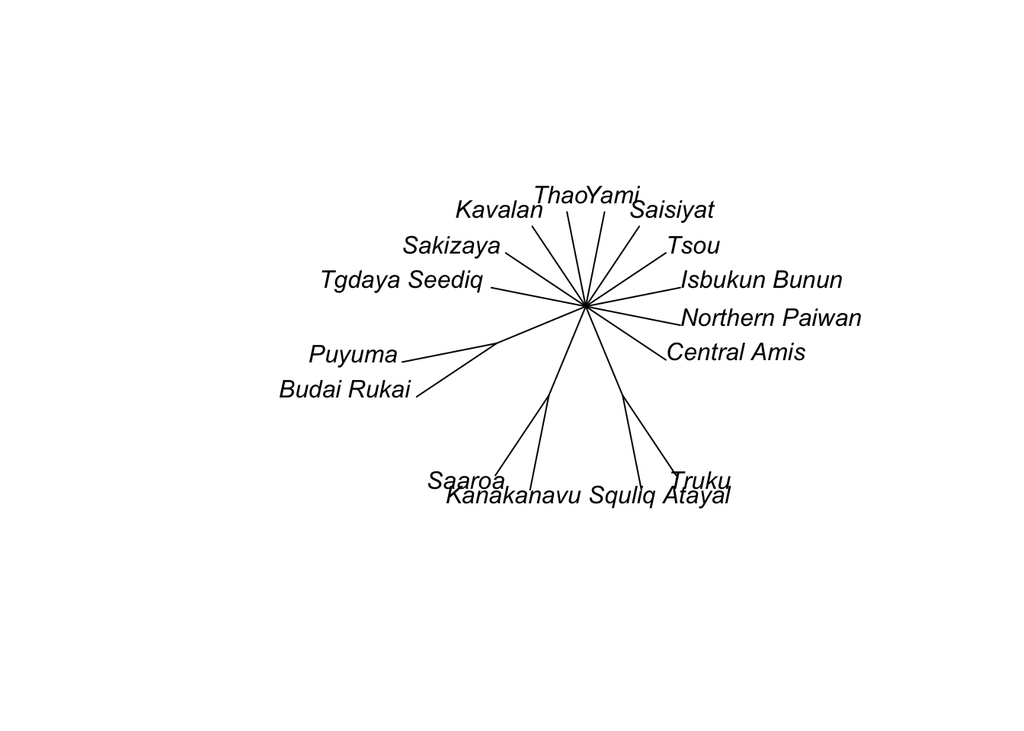

```r
x = x[order(x$Node),]
#x$Geo = as.factor(x$Geo)
#plot(btr.consensus, type = "u", font = as.numeric(x$Geography))
plot(btr.consensus, type = "u")
```

## Estimating phylogenetic trees with phangorn

```r
austroTW.2 <- read_csv("formosan_dummies.csv")
head(phylogeny)
```

```
##   Language Family Frics PrenasalizedStops PhonDistBetweenLAndR
## 1   Motuna Papuan     1                 0                    0
## 2      Kol Papuan     1                 0                    1
## 3  Rotokas Papuan     1                 0                    0
## 4      Ata Papuan     1                 0                    0
## 5     Kuot Papuan     1                 0                    1
## 6     Touo Papuan     1                 1                    0
##   PhonVelarFricOrGlide PhonVoicingContrAmongStops PhonConsLength
## 1                    0                          0              0
## 2                    0                          1              0
## 3                    0                          1              0
## 4                    1                          0              0
## 5                    0                          1              0
## 6                    1                          1              0
##   PhonVowelLength ContrPhonTypesForVowels PhonStress WordFinalConss
```

[output cut: 195 more lines]

```r
pdf("austroTW_tr.pdf", height=1.85)

par(mfrow=c(1,3), mai = c(0.01, 0.01, 0.01, 0.01))

plot(austroTW.dist.tr, type="u", font=geo_label)

plot(austroTW.dist.tr, type="u")
# add the thermometers
nodelabels(thermo = props, piecol = c("blue", "grey"))

plot(btr.consensus, type = "u")

dev.off()
```